# Phụ lục 1: Mã nguồn bài toán Ảnh hưởng của Học vấn đến Thu nhập.

Trong nội dung Khóa luận về Suy luận nhân quả và Double Machine Learning, bài toán Ảnh hưởng của Học vấn đến thu nhập là một trong hai bài toán đề ra trong nội dung. Bài toán này xem xét ảnh hưởng của thu nhập người dân khi học vấn tăng lên, được nghiên cứu bởi David Card.

Đầu tiên, chúng ta import các thư viện cần thiết cho áp dụng các kỹ thuật. Bộ dữ liệu được tích hợp trong package **causaldata**, **doubleml** được sử dụng cho Double Machine Learning.

```python
import numpy as np
import pandas as pd
import doubleml as dml
from sklearn.ensemble import RandomForestClassifier, RandomForestRegressor
import matplotlib.pyplot as plt
from causaldata import close_college
import seaborn as sns
import statsmodels.formula.api as smf
import statsmodels.api as sm
from sklearn.linear_model import LinearRegression
from statsmodels.sandbox.regression.gmm import IV2SLS
```

## Thông tin bài toán

Chúng ta import dữ liệu bài toán từ package và mô tả dữ liệu.

```python
data = close_college.load_pandas().data
df_data = pd.DataFrame(data)
df_data=df_data.dropna()
print(df_data.info())
print(df_data.head(10))
print(df_data.describe())
```

```
<class 'pandas.core.frame.DataFrame'>
Index: 3003 entries, 0 to 3009
Data columns (total 8 columns):
 #   Column   Non-Null Count  Dtype
---  ------   --------------  -----
 0   nearc4   3003 non-null   int8
 1   educ     3003 non-null   int8
 2   black    3003 non-null   int8
 3   smsa     3003 non-null   int8
 4   south    3003 non-null   int8
 5   married  3003 non-null   float64
 6   exper    3003 non-null   int8
 7   lwage    3003 non-null   float32
dtypes: float32(1), float64(1), int8(6)
memory usage: 76.2 KB
None
   nearc4  educ  black  smsa  south  married  exper     lwage
0       0     7      1     1      0      1.0     16  6.306275
1       0    12      0     1      0      1.0      9  6.175867
2       0    12      0     1      0      1.0     16  6.580639
3       1    11      0     1      0      1.0     10  5.521461
4       1    12      0     1      0      1.0     16  6.591674
5       1    12      0     1      0      1.0      8  6.214608
6       1    18      0     1      0      1.0      9  6.336826
7       1    14      0     1      0      1.0      9  6.410175
8       1    12      0     1      0      4.0     10  6.052089
9       1    12      0     1      0      1.0     11  6.244167
            nearc4         educ        black         smsa        south  \
count  3003.000000  3003.000000  3003.000000  3003.000000  3003.000000
mean      0.682984    13.266400     0.232767     0.713287     0.403929
std       0.465391     2.677221     0.422666     0.452302     0.490765
min       0.000000     1.000000     0.000000     0.000000     0.000000
25%       0.000000    12.000000     0.000000     0.000000     0.000000
50%       1.000000    13.000000     0.000000     1.000000     0.000000
75%       1.000000    16.000000     0.000000     1.000000     1.000000
max       1.000000    18.000000     1.000000     1.000000     1.000000

           married        exper        lwage
count  3003.000000  3003.000000  3003.000000
mean      2.271395     8.857476     6.262149
std       2.066823     4.141525     0.443684
min       1.000000     0.000000     4.605170
25%       1.000000     6.000000     5.980150
50%       1.000000     8.000000     6.287858
75%       4.000000    11.000000     6.563150
max       6.000000    23.000000     7.784889
```

Các biến có trong bộ dữ liệu bao gồm:

• **lwage**: Tiền lương

• **educ**: Số năm học tập

• **exper**: Số năm kinh nghiệm làm việc

• **south**: Là người miền nam nước Mỹ

• **married**: Đã kết hôn

• **smsa**: Ở vùng đô thị

• **nearc4**: Có trường đại học nằm trong khu vực sinh sống

Chúng ta sẽ biểu diễn hình ảnh cho bộ dữ liệu của bài toán. Trong đó trục hoành biểu diễn học vấn **educ**, trục tung biểu diễn mức lương **lwage**. Bên cạnh đó chúng ta sẽ biểu diễn ma trận tương quan của bộ dữ liệu.

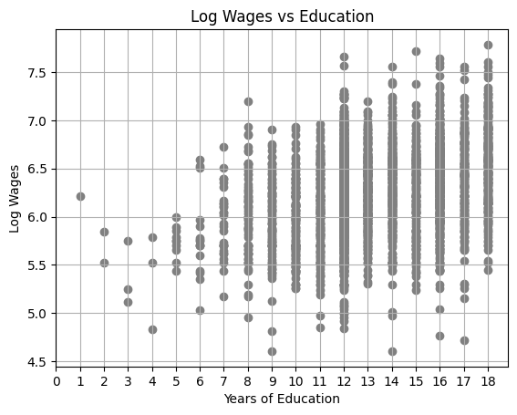

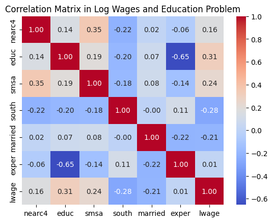

```python
plt.scatter(df_data['educ'], df_data['lwage'], color='gray')
plt.title('Log Wages vs Education')
plt.xlabel('Years of Education')
plt.ylabel('Log Wages')
plt.xticks(range(0, max(df_data['educ']) + 1, 1))
plt.grid(True)
plt.show()


df_data_drop_black = df_data.drop(columns='black')
correlation_matrix = df_data_drop_black.corr()
sns.heatmap(correlation_matrix, annot=True, cmap='coolwarm', fmt=".2f")
plt.title('Correlation Matrix in Log Wages and Education Problem')
plt.show()
```

## Ước lượng và kết quả thực nghiệm

Bây giờ chúng ta sẽ thực hiện *Linear Regression* và *2SLS* cho bộ dữ liệu này tương tự như nghiên cứu của David Card.

```python
X = df_data[['educ', 'exper', 'black', 'south', 'married', 'smsa', 'nearc4']]
y = df_data['lwage']

model_sklearn = LinearRegression()
X = df_data[['educ', 'exper', 'black', 'south', 'married', 'smsa', 'nearc4']]
model_sklearn.fit(X, y)
print('Hệ số của biến educ lên biến lwage:', model_sklearn.coef_[0])
```

```
Hệ số của biến educ lên biến lwage: 0.07089398007630289
```

```python
Z = df_data[['nearc4']]
D = df_data[['educ']]
X = df_data[['exper', 'black', 'south', 'married', 'smsa']]
y = df_data['lwage']
X = sm.add_constant(X)
exog = pd.concat([D, X], axis=1)
instruments = pd.concat([Z, X], axis=1)
iv2sls = IV2SLS(y, exog, instrument=instruments).fit()
print(iv2sls.summary())
```

```
                          IV2SLS Regression Results
==============================================================================
Dep. Variable:                  lwage   R-squared:                       0.251
Model:                         IV2SLS   Adj. R-squared:                  0.250
Method:                     Two Stage   F-statistic:                     139.8
                        Least Squares   Prob (F-statistic):          1.28e-156
Date:                Tue, 28 May 2024
Time:                        11:04:40
No. Observations:                3003
Df Residuals:                    2996
Df Model:                           6
==============================================================================
                 coef    std err          t      P>|t|      [0.025      0.975]
------------------------------------------------------------------------------
educ           0.1242      0.050      2.485      0.013       0.026       0.222
const          4.1625      0.850      4.899      0.000       2.497       5.828
exper          0.0556      0.020      2.740      0.006       0.016       0.095
black         -0.1157      0.051     -2.280      0.023      -0.215      -0.016
south         -0.1132      0.023     -4.869      0.000      -0.159      -0.068
married       -0.0320      0.005     -6.286      0.000      -0.042      -0.022
smsa           0.1477      0.031      4.781      0.000       0.087       0.208
==============================================================================
Omnibus:                       51.414   Durbin-Watson:                   1.872
Prob(Omnibus):                  0.000   Jarque-Bera (JB):               65.690
Skew:                          -0.232   Prob(JB):                     5.44e-15
Kurtosis:                       3.556   Cond. No.                         154.
==============================================================================
```

Kết quả cho thấy hệ số của biến educ lên biến lwage trong mô hình *Linear Regression* là khoảng 7.1%, trong khi đối với *2SLS* là 12.4%, tương tự như kết quả của Card.

Chúng ta sẽ thực hiện DML cho ước lượng ảnh hưởng của biến educ lên biến lwage. Chúng ta sẽ thực hiện 2 mô hình DML cho bài toán này: Một mô hình *PLR*, một mô hình *PLIV*.

```python
feature_plr = ['exper', 'married', 'south', 'black', 'smsa', 'nearc4']
dml_data_plr_base = dml.DoubleMLData(df_data, y_col='lwage', x_cols=feature_plr, d_cols='educ')
print(dml_data_plr_base)
```

```
================== DoubleMLData Object ==================

------------------ Data summary      ------------------
Outcome variable: lwage
Treatment variable(s): ['educ']
Covariates: ['exper', 'married', 'south', 'black', 'smsa', 'nearc4']
Instrument variable(s): None
No. Observations: 3003

------------------ DataFrame info    ------------------
<class 'pandas.core.frame.DataFrame'>
Index: 3003 entries, 0 to 3009
Columns: 8 entries, nearc4 to lwage
dtypes: float32(1), float64(1), int8(6)
memory usage: 76.2 KB
```

```python
feature_pliv = ['exper', 'married', 'south', 'black', 'smsa']
instrument_feature = ['nearc4']
dml_data_pliv_base = dml.DoubleMLData(df_data, y_col='lwage', x_cols=feature_pliv, d_cols='educ', z_cols=instrument_feature)
print(dml_data_pliv_base)
```

```
================== DoubleMLData Object ==================

------------------ Data summary      ------------------
Outcome variable: lwage
Treatment variable(s): ['educ']
Covariates: ['exper', 'married', 'south', 'black', 'smsa']
Instrument variable(s): ['nearc4']
No. Observations: 3003

------------------ DataFrame info    ------------------
<class 'pandas.core.frame.DataFrame'>
Index: 3003 entries, 0 to 3009
Columns: 8 entries, nearc4 to lwage
dtypes: float32(1), float64(1), int8(6)
memory usage: 76.2 KB
```

```python
ml_l = RandomForestRegressor(n_estimators=100, max_features=20, max_depth=5, min_samples_leaf=2)
ml_m = RandomForestRegressor(n_estimators=100, max_features=20, max_depth=5, min_samples_leaf=2)
np.random.seed(123)
dml_plr_obj = dml.DoubleMLPLR(dml_data_plr_base, ml_l=ml_l, ml_m=ml_m)
print(dml_plr_obj.fit())
```

```
================== DoubleMLPLR Object ==================

------------------ Data summary      ------------------
Outcome variable: lwage
Treatment variable(s): ['educ']
Covariates: ['exper', 'married', 'south', 'black', 'smsa', 'nearc4']
Instrument variable(s): None
No. Observations: 3003

------------------ Score & algorithm ------------------
Score function: partialling out
DML algorithm: dml2

------------------ Machine learner   ------------------
Learner ml_l: RandomForestRegressor(max_depth=5, max_features=20, min_samples_leaf=2)
Learner ml_m: RandomForestRegressor(max_depth=5, max_features=20, min_samples_leaf=2)
Out-of-sample Performance:
Learner ml_l RMSE: [[0.39510432]]
Learner ml_m RMSE: [[1.88230659]]

------------------ Resampling        ------------------
No. folds: 5
No. repeated sample splits: 1
Apply cross-fitting: True

------------------ Fit summary       ------------------
          coef   std err          t         P>|t|     2.5 %    97.5 %
educ  0.070806  0.003727  18.997432  1.790962e-80  0.063501  0.078111
```

```python
ml_l_rf = RandomForestRegressor(n_estimators=100, max_features=20, max_depth=5, min_samples_leaf=2)
ml_m_rf = RandomForestRegressor(n_estimators=100, max_features=20, max_depth=5, min_samples_leaf=2)
ml_r_rf = RandomForestRegressor(n_estimators=100, max_features=20, max_depth=5, min_samples_leaf=2)
np.random.seed(123)
dml_pliv_obj_rf = dml.DoubleMLPLIV(dml_data_pliv_base, ml_l=ml_l_rf, ml_m=ml_m_rf, ml_r=ml_r_rf)
print(dml_pliv_obj_rf.fit())
```

```
================== DoubleMLPLIV Object ==================

------------------ Data summary      ------------------
Outcome variable: lwage
Treatment variable(s): ['educ']
Covariates: ['exper', 'married', 'south', 'black', 'smsa']
Instrument variable(s): ['nearc4']
No. Observations: 3003

------------------ Score & algorithm ------------------
Score function: partialling out
DML algorithm: dml2

------------------ Machine learner   ------------------
Learner ml_l: RandomForestRegressor(max_depth=5, max_features=20, min_samples_leaf=2)
Learner ml_m: RandomForestRegressor(max_depth=5, max_features=20, min_samples_leaf=2)
Learner ml_r: RandomForestRegressor(max_depth=5, max_features=20, min_samples_leaf=2)
Out-of-sample Performance:
Learner ml_l RMSE: [[0.39525895]]
Learner ml_m RMSE: [[0.43192447]]
Learner ml_r RMSE: [[1.88014373]]

------------------ Resampling        ------------------
No. folds: 5
No. repeated sample splits: 1
Apply cross-fitting: True

------------------ Fit summary       ------------------
          coef   std err         t     P>|t|     2.5 %    97.5 %
educ  0.123766  0.045021  2.749084  0.005976  0.035527  0.212005
```

Chúng ta thấy kết quả ước lượng có sự nhất quán với nghiên cứu của Card. Đối với *Linear Regression*, mô hình *PLR* cho thấy sự tương đồng, trong khi mô hình *PLIV* cho thấy kết quả nhất quán với nghiên cứu của Card khi xem xét biến **nearc4** là biến công cụ.

```python
df_summary = pd.concat((dml_plr_obj.summary, dml_pliv_obj_rf.summary))

df_summary.index = ['PLR', 'PLIV']
print(df_summary)
```

```
          coef   std err          t         P>|t|     2.5 %    97.5 %
PLR   0.070806  0.003727  18.997432  1.790962e-80  0.063501  0.078111
PLIV  0.123766  0.045021   2.749084  5.976202e-03  0.035527  0.212005
```

Kết quả khoảng tin cậy cho thấy ảnh hưởng của biến **educ** lên biến **lwage** có giá trị dương, tức là học vấn tăng lên sẽ tăng thu nhập.

Nguyên nhân cho khác biệt kết quả của bài toán khi thực hiện các phương pháp khác nhau đến từ sự tham gia của biến **nearc4**. Việc có trường đại học gần với khu vực mình sống có tác động đến học vấn (một người có thể có xu hướng học trường gần với khu vực mình sinh sống hơn) nhưng không ảnh hưởng trực tiếp đến thu nhập. Do đó biến **nearc4** đóng vai trò như một biến công cụ, ảnh hưởng đến biến can thiệp **educ** và không ảnh hưởng đến biến kết quả **lwage**.

Khoảng cách giữa các trường đại học có thể đóng vai trò ảnh hưởng tới quyết định việc đi học, vì người học lớn lên ở khu vực không có trường đại học sẽ phải đối mặt với chi phí cho việc học đại học cao hơn.

## Tài liệu tham khảo

Card, David. 1995. "Aspects of Labour Economics: Essays in Honour of John Vanderkamp." In University of Toronto Press.

Cunningham, Scott. 2021. Causal Inference: The Mixtape.

Chernozhukov, V., Chetverikov, D., Demirer, M., Duflo, E., Hansen, C., Newey, W., and Robins, J. 2018. "Double/debiased machine learning for treatment and structural parameters." The Econometrics Journal, 21: C1-C68. doi:10.1111/ectj.12097.

Bach, P., Chernozhukov, V., Kurz, M. S., and Spindler, M. 2022. "DoubleML - An Object-Oriented Implementation of Double Machine Learning in Python." Journal of Machine Learning Research, 23(53): 1-6. Available at: https://www.jmlr.org/papers/v23/21-0862.html.

Bach, P., Chernozhukov, V., Kurz, M. S., Spindler, M., and Klaassen, S. 2024. "DoubleML - An Object-Oriented Implementation of Double Machine Learning in R." Journal of Statistical Software, 108(3): 1-56. doi:10.18637/jss.v108.i03, arXiv:2103.09603.